# Otus Machine Learning Course. Homework №1

### Воротников Владимир

Общее описание задачи:

ML 101. Учимся работе с данными - от загрузки до моделирования.

Цель: В этом домашнем задании вам предстоит поработать с достаточно небольшим, но интересным датасетом по раку груди.

Признаками в этом наборе данных являются различные измерения образований в груди, такие как радиус, симметричность, и т.д.

Целевая переменная - диагноз, является ли новообразование злокачественным или нет.

```python
import itertools
import numpy as np
import pandas as pd
import scipy as sp
import seaborn as sns

%matplotlib notebook
import matplotlib.pyplot as plt

from IPython.display import display
```

## Part 1. EDA

### Формулировка первой части задачи:

Часть 1. EDA

1. Скачайте датасет по ссылке: https://www.kaggle.com/uciml/breast-cancer-wisconsin-data
2. Посмотрите на базовые статистики датасета: средние, медианы, и т.д.
3. Постройте гистограммы/распределения признаков, при этом используйте целевую переменную, чтобы сгруппировать и раскрасить гистограммы
4. Постройте heatmap для матрицы корреляций, есть ли признаки, которые сильно скоррелированы? Какие это признаки?
5. Постройте для сильно скоррелированных признаков попарные scatterplot-ы, действительно ли наблюдается линейная зависимость?
6. Используя boxplots и группировку по целевой переменной, попробуйте предположить, по каким признакам наиболее удобно было бы отделить злокачественные новообразования от доброкачественных

Также очень приветствуется ваша инициатива по визуализациям и исследовании данных :)

```python
data = pd.read_csv('data/data.csv')
```

### Basic data information

```python
print("Data shape is {0}.\n\nExample of the data: \n{1}".format(data.shape, data.head(3)))
```

```
Data shape is (569, 33).

Example of the data:
         id diagnosis  radius_mean  texture_mean  perimeter_mean  area_mean  \
0    842302         M        17.99         10.38           122.8     1001.0
1    842517         M        20.57         17.77           132.9     1326.0
2  84300903         M        19.69         21.25           130.0     1203.0

   smoothness_mean  compactness_mean  concavity_mean  concave points_mean  \
0          0.11840           0.27760          0.3001              0.14710
1          0.08474           0.07864          0.0869              0.07017
2          0.10960           0.15990          0.1974              0.12790

   ...  texture_worst  perimeter_worst  area_worst  smoothness_worst  \
0  ...          17.33            184.6      2019.0            0.1622
1  ...          23.41            158.8      1956.0            0.1238
2  ...          25.53            152.5      1709.0            0.1444

   compactness_worst  concavity_worst  concave points_worst  symmetry_worst  \
0             0.6656           0.7119                0.2654          0.4601
1             0.1866           0.2416                0.1860          0.2750
2             0.4245           0.4504                0.2430          0.3613

   fractal_dimension_worst  Unnamed: 32
0                  0.11890          NaN
1                  0.08902          NaN
2                  0.08758          NaN

[3 rows x 33 columns]
```

```python
data = data.drop('Unnamed: 32', axis=1)
data.loc[:, data.columns!='id'].describe(percentiles=[0.1, 0.25, 0.75, .9])
```

|  | radius_mean | texture_mean | perimeter_mean | area_mean | smoothness_mean | compactness_mean | concavity_mean | concave points_mean | symmetry_mean | fractal_dimension_mean | ... | radius_worst | texture_worst | perimeter_worst | area_worst | smoothness_worst | compactness_worst | concavity_worst | concave points_worst | symmetry_worst | fractal_dimension_worst |
| --- | --- | --- | --- | --- | --- | --- | --- | --- | --- | --- | --- | --- | --- | --- | --- | --- | --- | --- | --- | --- | --- |
| count | 569.000000 | 569.000000 | 569.000000 | 569.000000 | 569.000000 | 569.000000 | 569.000000 | 569.000000 | 569.000000 | 569.000000 | ... | 569.000000 | 569.000000 | 569.000000 | 569.000000 | 569.000000 | 569.000000 | 569.000000 | 569.000000 | 569.000000 | 569.000000 |
| mean | 14.127292 | 19.289649 | 91.969033 | 654.889104 | 0.096360 | 0.104341 | 0.088799 | 0.048919 | 0.181162 | 0.062798 | ... | 16.269190 | 25.677223 | 107.261213 | 880.583128 | 0.132369 | 0.254265 | 0.272188 | 0.114606 | 0.290076 | 0.083946 |
| std | 3.524049 | 4.301036 | 24.298981 | 351.914129 | 0.014064 | 0.052813 | 0.079720 | 0.038803 | 0.027414 | 0.007060 | ... | 4.833242 | 6.146258 | 33.602542 | 569.356993 | 0.022832 | 0.157336 | 0.208624 | 0.065732 | 0.061867 | 0.018061 |
| min | 6.981000 | 9.710000 | 43.790000 | 143.500000 | 0.052630 | 0.019380 | 0.000000 | 0.000000 | 0.106000 | 0.049960 | ... | 7.930000 | 12.020000 | 50.410000 | 185.200000 | 0.071170 | 0.027290 | 0.000000 | 0.000000 | 0.156500 | 0.055040 |
| 10% | 10.260000 | 14.078000 | 65.830000 | 321.600000 | 0.079654 | 0.049700 | 0.013686 | 0.011158 | 0.149580 | 0.055338 | ... | 11.234000 | 17.800000 | 72.178000 | 384.720000 | 0.102960 | 0.093676 | 0.045652 | 0.038460 | 0.226120 | 0.065792 |
| 25% | 11.700000 | 16.170000 | 75.170000 | 420.300000 | 0.086370 | 0.064920 | 0.029560 | 0.020310 | 0.161900 | 0.057700 | ... | 13.010000 | 21.080000 | 84.110000 | 515.300000 | 0.116600 | 0.147200 | 0.114500 | 0.064930 | 0.250400 | 0.071460 |
| 50% | 13.370000 | 18.840000 | 86.240000 | 551.100000 | 0.095870 | 0.092630 | 0.061540 | 0.033500 | 0.179200 | 0.061540 | ... | 14.970000 | 25.410000 | 97.660000 | 686.500000 | 0.131300 | 0.211900 | 0.226700 | 0.099930 | 0.282200 | 0.080040 |
| 75% | 15.780000 | 21.800000 | 104.100000 | 782.700000 | 0.105300 | 0.130400 | 0.130700 | 0.074000 | 0.195700 | 0.066120 | ... | 18.790000 | 29.720000 | 125.400000 | 1084.000000 | 0.146000 | 0.339100 | 0.382900 | 0.161400 | 0.317900 | 0.092080 |
| 90% | 19.530000 | 24.992000 | 129.100000 | 1177.400000 | 0.114820 | 0.175460 | 0.203040 | 0.100420 | 0.214940 | 0.072266 | ... | 23.682000 | 33.646000 | 157.740000 | 1673.000000 | 0.161480 | 0.447840 | 0.571320 | 0.208940 | 0.360080 | 0.106320 |
| max | 28.110000 | 39.280000 | 188.500000 | 2501.000000 | 0.163400 | 0.345400 | 0.426800 | 0.201200 | 0.304000 | 0.097440 | ... | 36.040000 | 49.540000 | 251.200000 | 4254.000000 | 0.222600 | 1.058000 | 1.252000 | 0.291000 | 0.663800 | 0.207500 |

10 rows × 30 columns

### Basic Statistics

```python
# Разбиваем на два блока в зависимости от целевой переменной
data_m = data[data['diagnosis'] == 'M']
data_b = data[data['diagnosis'] == 'B']

# Дополнительно найдем те параметры, где отклонение среднего у целевого параметра
# превышает стандартное отклонение от общего среднего
d1 = (abs(data_b.mean() - data.mean()) - data.std()) > 0
d2 = (abs(data_m.mean() - data.mean()) - data.std()) > 0

stats = pd.concat([data_m.mean().round(3).rename('Mean (Maligant)'),
           data_b.mean().round(3).rename('Mean (Benign)'),
           data.mean().round(3).rename('Mean (Total)'),
           data.std().rename('Std (Total)'),
           (d1|d2).rename('Out of std'),
           data_m.median().round(3).rename('Median (Maligant)'),
           data_b.median().round(3).rename('Median (Benign)'),
           data.median().round(3).rename('Median (Total)'),],
          axis=1)
stats = stats.loc[stats.index!='id']
display(stats)
# Таких параметров нашлось 4
```

|  | Mean (Maligant) | Mean (Benign) | Mean (Total) | Std (Total) | Out of std | Median (Maligant) | Median (Benign) | Median (Total) |
| --- | --- | --- | --- | --- | --- | --- | --- | --- |
| radius_mean | 17.463 | 12.147 | 14.127 | 3.524049 | False | 17.325 | 12.200 | 13.370 |
| texture_mean | 21.605 | 17.915 | 19.290 | 4.301036 | False | 21.460 | 17.390 | 18.840 |
| perimeter_mean | 115.365 | 78.075 | 91.969 | 24.298981 | False | 114.200 | 78.180 | 86.240 |
| area_mean | 978.376 | 462.790 | 654.889 | 351.914129 | False | 932.000 | 458.400 | 551.100 |
| smoothness_mean | 0.103 | 0.092 | 0.096 | 0.014064 | False | 0.102 | 0.091 | 0.096 |
| compactness_mean | 0.145 | 0.080 | 0.104 | 0.052813 | False | 0.132 | 0.075 | 0.093 |
| concavity_mean | 0.161 | 0.046 | 0.089 | 0.079720 | False | 0.151 | 0.037 | 0.062 |
| concave points_mean | 0.088 | 0.026 | 0.049 | 0.038803 | True | 0.086 | 0.023 | 0.034 |
| symmetry_mean | 0.193 | 0.174 | 0.181 | 0.027414 | False | 0.190 | 0.171 | 0.179 |
| fractal_dimension_mean | 0.063 | 0.063 | 0.063 | 0.007060 | False | 0.062 | 0.062 | 0.062 |
| radius_se | 0.609 | 0.284 | 0.405 | 0.277313 | False | 0.547 | 0.258 | 0.324 |
| texture_se | 1.211 | 1.220 | 1.217 | 0.551648 | False | 1.102 | 1.108 | 1.108 |
| perimeter_se | 4.324 | 2.000 | 2.866 | 2.021855 | False | 3.680 | 1.851 | 2.287 |
| area_se | 72.672 | 21.135 | 40.337 | 45.491006 | False | 58.455 | 19.630 | 24.530 |
| smoothness_se | 0.007 | 0.007 | 0.007 | 0.003003 | False | 0.006 | 0.007 | 0.006 |
| compactness_se | 0.032 | 0.021 | 0.025 | 0.017908 | False | 0.029 | 0.016 | 0.020 |
| concavity_se | 0.042 | 0.026 | 0.032 | 0.030186 | False | 0.037 | 0.018 | 0.026 |
| concave points_se | 0.015 | 0.010 | 0.012 | 0.006170 | False | 0.014 | 0.009 | 0.011 |
| symmetry_se | 0.020 | 0.021 | 0.021 | 0.008266 | False | 0.018 | 0.019 | 0.019 |
| fractal_dimension_se | 0.004 | 0.004 | 0.004 | 0.002646 | False | 0.004 | 0.003 | 0.003 |
| radius_worst | 21.135 | 13.380 | 16.269 | 4.833242 | True | 20.590 | 13.350 | 14.970 |
| texture_worst | 29.318 | 23.515 | 25.677 | 6.146258 | False | 28.945 | 22.820 | 25.410 |
| perimeter_worst | 141.370 | 87.006 | 107.261 | 33.602542 | True | 138.000 | 86.920 | 97.660 |
| area_worst | 1422.286 | 558.899 | 880.583 | 569.356993 | False | 1303.000 | 547.400 | 686.500 |
| smoothness_worst | 0.145 | 0.125 | 0.132 | 0.022832 | False | 0.143 | 0.125 | 0.131 |
| compactness_worst | 0.375 | 0.183 | 0.254 | 0.157336 | False | 0.356 | 0.170 | 0.212 |
| concavity_worst | 0.451 | 0.166 | 0.272 | 0.208624 | False | 0.405 | 0.141 | 0.227 |
| concave points_worst | 0.182 | 0.074 | 0.115 | 0.065732 | True | 0.182 | 0.074 | 0.100 |
| symmetry_worst | 0.323 | 0.270 | 0.290 | 0.061867 | False | 0.310 | 0.269 | 0.282 |
| fractal_dimension_worst | 0.092 | 0.079 | 0.084 | 0.018061 | False | 0.088 | 0.077 | 0.080 |

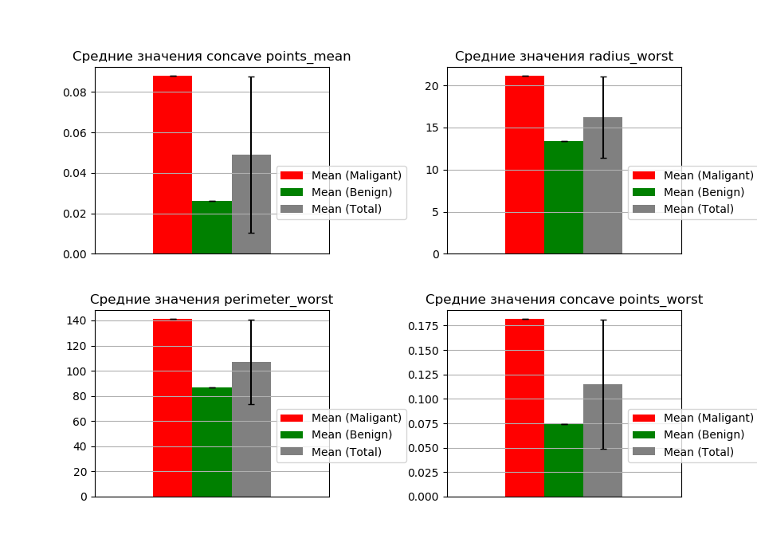

```python
# по этим четырём параметрам построим гистограммы

stats_out = stats[stats['Out of std'] == True]

means = stats_out[stats_out.columns[0:3]]
errors = (stats_out[stats_out.columns[3]])

errors = pd.concat([pd.Series(0.0, index=errors.index),
                    pd.Series(0.0, index=errors.index),
                    errors],
                   axis=1)
errors.columns = means.columns

fig = plt.figure(figsize=(9.5,7))

ax_list = []
for a in range(1,5):
    ax_list.append(fig.add_subplot(2, 2, a))

plt.subplots_adjust(wspace=0.5, hspace=0.3)
curr_ax=0

for i in means.index:
    means[means.index==i].plot.bar(grid=True,
                                   yerr=errors[errors.index==i],
                                   capsize=3,
                                   title="Средние значения {0}".format(i),
                                   color=['r','g','grey'],
                                   ax=ax_list[curr_ax],
                                   xticks=[]).legend(bbox_to_anchor=(0.75, 0.5))
    curr_ax += 1
```

### Searching for correlation

```python
data_corr = data.loc[:, data.columns!='id'].corr()
display(data_corr)
```

|  | radius_mean | texture_mean | perimeter_mean | area_mean | smoothness_mean | compactness_mean | concavity_mean | concave points_mean | symmetry_mean | fractal_dimension_mean | ... | radius_worst | texture_worst | perimeter_worst | area_worst | smoothness_worst | compactness_worst | concavity_worst | concave points_worst | symmetry_worst | fractal_dimension_worst |
| --- | --- | --- | --- | --- | --- | --- | --- | --- | --- | --- | --- | --- | --- | --- | --- | --- | --- | --- | --- | --- | --- |
| radius_mean | 1.000000 | 0.323782 | 0.997855 | 0.987357 | 0.170581 | 0.506124 | 0.676764 | 0.822529 | 0.147741 | -0.311631 | ... | 0.969539 | 0.297008 | 0.965137 | 0.941082 | 0.119616 | 0.413463 | 0.526911 | 0.744214 | 0.163953 | 0.007066 |
| texture_mean | 0.323782 | 1.000000 | 0.329533 | 0.321086 | -0.023389 | 0.236702 | 0.302418 | 0.293464 | 0.071401 | -0.076437 | ... | 0.352573 | 0.912045 | 0.358040 | 0.343546 | 0.077503 | 0.277830 | 0.301025 | 0.295316 | 0.105008 | 0.119205 |
| perimeter_mean | 0.997855 | 0.329533 | 1.000000 | 0.986507 | 0.207278 | 0.556936 | 0.716136 | 0.850977 | 0.183027 | -0.261477 | ... | 0.969476 | 0.303038 | 0.970387 | 0.941550 | 0.150549 | 0.455774 | 0.563879 | 0.771241 | 0.189115 | 0.051019 |
| area_mean | 0.987357 | 0.321086 | 0.986507 | 1.000000 | 0.177028 | 0.498502 | 0.685983 | 0.823269 | 0.151293 | -0.283110 | ... | 0.962746 | 0.287489 | 0.959120 | 0.959213 | 0.123523 | 0.390410 | 0.512606 | 0.722017 | 0.143570 | 0.003738 |
| smoothness_mean | 0.170581 | -0.023389 | 0.207278 | 0.177028 | 1.000000 | 0.659123 | 0.521984 | 0.553695 | 0.557775 | 0.584792 | ... | 0.213120 | 0.036072 | 0.238853 | 0.206718 | 0.805324 | 0.472468 | 0.434926 | 0.503053 | 0.394309 | 0.499316 |
| compactness_mean | 0.506124 | 0.236702 | 0.556936 | 0.498502 | 0.659123 | 1.000000 | 0.883121 | 0.831135 | 0.602641 | 0.565369 | ... | 0.535315 | 0.248133 | 0.590210 | 0.509604 | 0.565541 | 0.865809 | 0.816275 | 0.815573 | 0.510223 | 0.687382 |
| concavity_mean | 0.676764 | 0.302418 | 0.716136 | 0.685983 | 0.521984 | 0.883121 | 1.000000 | 0.921391 | 0.500667 | 0.336783 | ... | 0.688236 | 0.299879 | 0.729565 | 0.675987 | 0.448822 | 0.754968 | 0.884103 | 0.861323 | 0.409464 | 0.514930 |
| concave points_mean | 0.822529 | 0.293464 | 0.850977 | 0.823269 | 0.553695 | 0.831135 | 0.921391 | 1.000000 | 0.462497 | 0.166917 | ... | 0.830318 | 0.292752 | 0.855923 | 0.809630 | 0.452753 | 0.667454 | 0.752399 | 0.910155 | 0.375744 | 0.368661 |
| symmetry_mean | 0.147741 | 0.071401 | 0.183027 | 0.151293 | 0.557775 | 0.602641 | 0.500667 | 0.462497 | 1.000000 | 0.479921 | ... | 0.185728 | 0.090651 | 0.219169 | 0.177193 | 0.426675 | 0.473200 | 0.433721 | 0.430297 | 0.699826 | 0.438413 |
| fractal_dimension_mean | -0.311631 | -0.076437 | -0.261477 | -0.283110 | 0.584792 | 0.565369 | 0.336783 | 0.166917 | 0.479921 | 1.000000 | ... | -0.253691 | -0.051269 | -0.205151 | -0.231854 | 0.504942 | 0.458798 | 0.346234 | 0.175325 | 0.334019 | 0.767297 |
| radius_se | 0.679090 | 0.275869 | 0.691765 | 0.732562 | 0.301467 | 0.497473 | 0.631925 | 0.698050 | 0.303379 | 0.000111 | ... | 0.715065 | 0.194799 | 0.719684 | 0.751548 | 0.141919 | 0.287103 | 0.380585 | 0.531062 | 0.094543 | 0.049559 |
| texture_se | -0.097317 | 0.386358 | -0.086761 | -0.066280 | 0.068406 | 0.046205 | 0.076218 | 0.021480 | 0.128053 | 0.164174 | ... | -0.111690 | 0.409003 | -0.102242 | -0.083195 | -0.073658 | -0.092439 | -0.068956 | -0.119638 | -0.128215 | -0.045655 |
| perimeter_se | 0.674172 | 0.281673 | 0.693135 | 0.726628 | 0.296092 | 0.548905 | 0.660391 | 0.710650 | 0.313893 | 0.039830 | ... | 0.697201 | 0.200371 | 0.721031 | 0.730713 | 0.130054 | 0.341919 | 0.418899 | 0.554897 | 0.109930 | 0.085433 |
| area_se | 0.735864 | 0.259845 | 0.744983 | 0.800086 | 0.246552 | 0.455653 | 0.617427 | 0.690299 | 0.223970 | -0.090170 | ... | 0.757373 | 0.196497 | 0.761213 | 0.811408 | 0.125389 | 0.283257 | 0.385100 | 0.538166 | 0.074126 | 0.017539 |
| smoothness_se | -0.222600 | 0.006614 | -0.202694 | -0.166777 | 0.332375 | 0.135299 | 0.098564 | 0.027653 | 0.187321 | 0.401964 | ... | -0.230691 | -0.074743 | -0.217304 | -0.182195 | 0.314457 | -0.055558 | -0.058298 | -0.102007 | -0.107342 | 0.101480 |
| compactness_se | 0.206000 | 0.191975 | 0.250744 | 0.212583 | 0.318943 | 0.738722 | 0.670279 | 0.490424 | 0.421659 | 0.559837 | ... | 0.204607 | 0.143003 | 0.260516 | 0.199371 | 0.227394 | 0.678780 | 0.639147 | 0.483208 | 0.277878 | 0.590973 |
| concavity_se | 0.194204 | 0.143293 | 0.228082 | 0.207660 | 0.248396 | 0.570517 | 0.691270 | 0.439167 | 0.342627 | 0.446630 | ... | 0.186904 | 0.100241 | 0.226680 | 0.188353 | 0.168481 | 0.484858 | 0.662564 | 0.440472 | 0.197788 | 0.439329 |
| concave points_se | 0.376169 | 0.163851 | 0.407217 | 0.372320 | 0.380676 | 0.642262 | 0.683260 | 0.615634 | 0.393298 | 0.341198 | ... | 0.358127 | 0.086741 | 0.394999 | 0.342271 | 0.215351 | 0.452888 | 0.549592 | 0.602450 | 0.143116 | 0.310655 |
| symmetry_se | -0.104321 | 0.009127 | -0.081629 | -0.072497 | 0.200774 | 0.229977 | 0.178009 | 0.095351 | 0.449137 | 0.345007 | ... | -0.128121 | -0.077473 | -0.103753 | -0.110343 | -0.012662 | 0.060255 | 0.037119 | -0.030413 | 0.389402 | 0.078079 |
| fractal_dimension_se | -0.042641 | 0.054458 | -0.005523 | -0.019887 | 0.283607 | 0.507318 | 0.449301 | 0.257584 | 0.331786 | 0.688132 | ... | -0.037488 | -0.003195 | -0.001000 | -0.022736 | 0.170568 | 0.390159 | 0.379975 | 0.215204 | 0.111094 | 0.591328 |
| radius_worst | 0.969539 | 0.352573 | 0.969476 | 0.962746 | 0.213120 | 0.535315 | 0.688236 | 0.830318 | 0.185728 | -0.253691 | ... | 1.000000 | 0.359921 | 0.993708 | 0.984015 | 0.216574 | 0.475820 | 0.573975 | 0.787424 | 0.243529 | 0.093492 |
| texture_worst | 0.297008 | 0.912045 | 0.303038 | 0.287489 | 0.036072 | 0.248133 | 0.299879 | 0.292752 | 0.090651 | -0.051269 | ... | 0.359921 | 1.000000 | 0.365098 | 0.345842 | 0.225429 | 0.360832 | 0.368366 | 0.359755 | 0.233027 | 0.219122 |
| perimeter_worst | 0.965137 | 0.358040 | 0.970387 | 0.959120 | 0.238853 | 0.590210 | 0.729565 | 0.855923 | 0.219169 | -0.205151 | ... | 0.993708 | 0.365098 | 1.000000 | 0.977578 | 0.236775 | 0.529408 | 0.618344 | 0.816322 | 0.269493 | 0.138957 |
| area_worst | 0.941082 | 0.343546 | 0.941550 | 0.959213 | 0.206718 | 0.509604 | 0.675987 | 0.809630 | 0.177193 | -0.231854 | ... | 0.984015 | 0.345842 | 0.977578 | 1.000000 | 0.209145 | 0.438296 | 0.543331 | 0.747419 | 0.209146 | 0.079647 |
| smoothness_worst | 0.119616 | 0.077503 | 0.150549 | 0.123523 | 0.805324 | 0.565541 | 0.448822 | 0.452753 | 0.426675 | 0.504942 | ... | 0.216574 | 0.225429 | 0.236775 | 0.209145 | 1.000000 | 0.568187 | 0.518523 | 0.547691 | 0.493838 | 0.617624 |
| compactness_worst | 0.413463 | 0.277830 | 0.455774 | 0.390410 | 0.472468 | 0.865809 | 0.754968 | 0.667454 | 0.473200 | 0.458798 | ... | 0.475820 | 0.360832 | 0.529408 | 0.438296 | 0.568187 | 1.000000 | 0.892261 | 0.801080 | 0.614441 | 0.810455 |
| concavity_worst | 0.526911 | 0.301025 | 0.563879 | 0.512606 | 0.434926 | 0.816275 | 0.884103 | 0.752399 | 0.433721 | 0.346234 | ... | 0.573975 | 0.368366 | 0.618344 | 0.543331 | 0.518523 | 0.892261 | 1.000000 | 0.855434 | 0.532520 | 0.686511 |
| concave points_worst | 0.744214 | 0.295316 | 0.771241 | 0.722017 | 0.503053 | 0.815573 | 0.861323 | 0.910155 | 0.430297 | 0.175325 | ... | 0.787424 | 0.359755 | 0.816322 | 0.747419 | 0.547691 | 0.801080 | 0.855434 | 1.000000 | 0.502528 | 0.511114 |
| symmetry_worst | 0.163953 | 0.105008 | 0.189115 | 0.143570 | 0.394309 | 0.510223 | 0.409464 | 0.375744 | 0.699826 | 0.334019 | ... | 0.243529 | 0.233027 | 0.269493 | 0.209146 | 0.493838 | 0.614441 | 0.532520 | 0.502528 | 1.000000 | 0.537848 |
| fractal_dimension_worst | 0.007066 | 0.119205 | 0.051019 | 0.003738 | 0.499316 | 0.687382 | 0.514930 | 0.368661 | 0.438413 | 0.767297 | ... | 0.093492 | 0.219122 | 0.138957 | 0.079647 | 0.617624 | 0.810455 | 0.686511 | 0.511114 | 0.537848 | 1.000000 |

30 rows × 30 columns

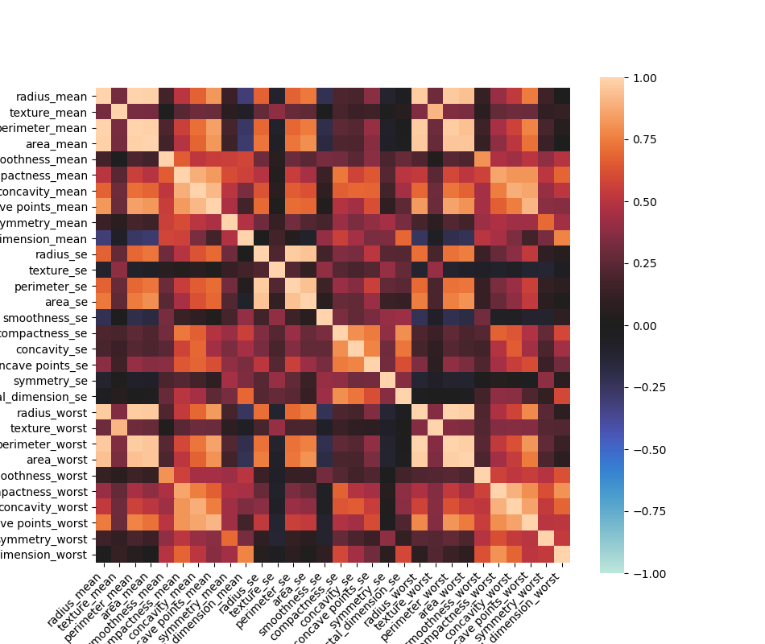

```
[]
```

```python
# Нарисуем heatmap для матрицы корреляций

fig = plt.figure(figsize=(9.5,8))
ax = sns.heatmap(
    data_corr,
    vmin=-1, vmax=1, center=0,
    square=True
)
ax.set_xticklabels(
    ax.get_xticklabels(),
    rotation=45,
    horizontalalignment='right'
)
ax.set_yticklabels(
    ax.get_yticklabels(),
    rotation=0,
)
ax.plot()
```

```python
# Найдем параметры с высокой корреляцией

CORRELATION_THRESHOLD = 0.90

# Stack-overflow-driven-development to remove duplicates from correlation matrix
corr_list = data_corr[abs(data_corr) >= 0.01].stack().reset_index()
corr_list = corr_list[corr_list['level_0'].astype(str)!=corr_list['level_1'].astype(str)]
# filtering out lower/upper triangular duplicates
corr_list['ordered-cols'] = corr_list.apply(lambda x: '-'.join(sorted([x['level_0'],x['level_1']])),axis=1)
corr_list = corr_list.drop_duplicates(['ordered-cols'])
corr_list.drop(['ordered-cols'], axis=1, inplace=True)

# rename and sort to find strongly correlated pairs
corr_list.columns = ['param_1', 'param_2', 'correlation']
corr_list['correlation'] = corr_list['correlation'].abs()
corr_list = corr_list.sort_values(by=['correlation'], ascending=False)

display(corr_list[corr_list['correlation'] > CORRELATION_THRESHOLD])
```

|  | param_1 | param_2 | correlation |
| --- | --- | --- | --- |
| 2 | radius_mean | perimeter_mean | 0.997855 |
| 610 | radius_worst | perimeter_worst | 0.993708 |
| 3 | radius_mean | area_mean | 0.987357 |
| 60 | perimeter_mean | area_mean | 0.986507 |
| 611 | radius_worst | area_worst | 0.984015 |
| 669 | perimeter_worst | area_worst | 0.977578 |
| 305 | radius_se | perimeter_se | 0.972794 |
| 78 | perimeter_mean | perimeter_worst | 0.970387 |
| 20 | radius_mean | radius_worst | 0.969539 |
| 76 | perimeter_mean | radius_worst | 0.969476 |
| 22 | radius_mean | perimeter_worst | 0.965137 |
| 106 | area_mean | radius_worst | 0.962746 |
| 109 | area_mean | area_worst | 0.959213 |
| 108 | area_mean | perimeter_worst | 0.959120 |
| 306 | radius_se | area_se | 0.951830 |
| 79 | perimeter_mean | area_worst | 0.941550 |
| 23 | radius_mean | area_worst | 0.941082 |
| 366 | perimeter_se | area_se | 0.937655 |
| 182 | concavity_mean | concave points_mean | 0.921391 |
| 48 | texture_mean | texture_worst | 0.912045 |
| 232 | concave points_mean | concave points_worst | 0.910155 |

[figure not shown]

```python
fig = plt.figure(figsize=(9.5,10))
ax_list = []
for a in range(1,9):
    ax_list.append(fig.add_subplot(4, 2, a))

plt.subplots_adjust(wspace=0.3, hspace=0.6)

curr_ax = 0
for i in range(8):
    x = data[corr_list.iloc[i]['param_1']]
    y = data[corr_list.iloc[i]['param_1']]
    ax_list[curr_ax].scatter(x, y,
                             marker='.',
                             color='b')
    ax_list[curr_ax].set_xlabel(corr_list.iloc[i]['param_1'])
    ax_list[curr_ax].set_ylabel(corr_list.iloc[i]['param_2'])
    ax_list[curr_ax].set_title('Correlation is {0}'.format(corr_list.iloc[i]['correlation']))
    curr_ax += 1
```

```python
# Удалим часть столбцов с высокой корреляцией
# Из групп высокоскоррелированных параметров:
# [radius_mean, perimeter_mean, area_mean, radius_worst, perimeter_worst, area_worst]
# [radius_se, perimeter_se, area_se]
# оставим по одному параметру
remove_list = ['id', 'perimeter_mean', 'area_mean', 'radius_worst',
               'perimeter_worst', 'area_worst', 'perimeter_se', 'area_se']
data_filtered = data.drop(remove_list, axis=1)

data_corr = data_filtered.corr()
display(data_corr)
```

|  | radius_mean | texture_mean | smoothness_mean | compactness_mean | concavity_mean | concave points_mean | symmetry_mean | fractal_dimension_mean | radius_se | texture_se | ... | concave points_se | symmetry_se | fractal_dimension_se | texture_worst | smoothness_worst | compactness_worst | concavity_worst | concave points_worst | symmetry_worst | fractal_dimension_worst |
| --- | --- | --- | --- | --- | --- | --- | --- | --- | --- | --- | --- | --- | --- | --- | --- | --- | --- | --- | --- | --- | --- |
| radius_mean | 1.000000 | 0.323782 | 0.170581 | 0.506124 | 0.676764 | 0.822529 | 0.147741 | -0.311631 | 0.679090 | -0.097317 | ... | 0.376169 | -0.104321 | -0.042641 | 0.297008 | 0.119616 | 0.413463 | 0.526911 | 0.744214 | 0.163953 | 0.007066 |
| texture_mean | 0.323782 | 1.000000 | -0.023389 | 0.236702 | 0.302418 | 0.293464 | 0.071401 | -0.076437 | 0.275869 | 0.386358 | ... | 0.163851 | 0.009127 | 0.054458 | 0.912045 | 0.077503 | 0.277830 | 0.301025 | 0.295316 | 0.105008 | 0.119205 |
| smoothness_mean | 0.170581 | -0.023389 | 1.000000 | 0.659123 | 0.521984 | 0.553695 | 0.557775 | 0.584792 | 0.301467 | 0.068406 | ... | 0.380676 | 0.200774 | 0.283607 | 0.036072 | 0.805324 | 0.472468 | 0.434926 | 0.503053 | 0.394309 | 0.499316 |
| compactness_mean | 0.506124 | 0.236702 | 0.659123 | 1.000000 | 0.883121 | 0.831135 | 0.602641 | 0.565369 | 0.497473 | 0.046205 | ... | 0.642262 | 0.229977 | 0.507318 | 0.248133 | 0.565541 | 0.865809 | 0.816275 | 0.815573 | 0.510223 | 0.687382 |
| concavity_mean | 0.676764 | 0.302418 | 0.521984 | 0.883121 | 1.000000 | 0.921391 | 0.500667 | 0.336783 | 0.631925 | 0.076218 | ... | 0.683260 | 0.178009 | 0.449301 | 0.299879 | 0.448822 | 0.754968 | 0.884103 | 0.861323 | 0.409464 | 0.514930 |
| concave points_mean | 0.822529 | 0.293464 | 0.553695 | 0.831135 | 0.921391 | 1.000000 | 0.462497 | 0.166917 | 0.698050 | 0.021480 | ... | 0.615634 | 0.095351 | 0.257584 | 0.292752 | 0.452753 | 0.667454 | 0.752399 | 0.910155 | 0.375744 | 0.368661 |
| symmetry_mean | 0.147741 | 0.071401 | 0.557775 | 0.602641 | 0.500667 | 0.462497 | 1.000000 | 0.479921 | 0.303379 | 0.128053 | ... | 0.393298 | 0.449137 | 0.331786 | 0.090651 | 0.426675 | 0.473200 | 0.433721 | 0.430297 | 0.699826 | 0.438413 |
| fractal_dimension_mean | -0.311631 | -0.076437 | 0.584792 | 0.565369 | 0.336783 | 0.166917 | 0.479921 | 1.000000 | 0.000111 | 0.164174 | ... | 0.341198 | 0.345007 | 0.688132 | -0.051269 | 0.504942 | 0.458798 | 0.346234 | 0.175325 | 0.334019 | 0.767297 |
| radius_se | 0.679090 | 0.275869 | 0.301467 | 0.497473 | 0.631925 | 0.698050 | 0.303379 | 0.000111 | 1.000000 | 0.213247 | ... | 0.513346 | 0.240567 | 0.227754 | 0.194799 | 0.141919 | 0.287103 | 0.380585 | 0.531062 | 0.094543 | 0.049559 |
| texture_se | -0.097317 | 0.386358 | 0.068406 | 0.046205 | 0.076218 | 0.021480 | 0.128053 | 0.164174 | 0.213247 | 1.000000 | ... | 0.230283 | 0.411621 | 0.279723 | 0.409003 | -0.073658 | -0.092439 | -0.068956 | -0.119638 | -0.128215 | -0.045655 |
| smoothness_se | -0.222600 | 0.006614 | 0.332375 | 0.135299 | 0.098564 | 0.027653 | 0.187321 | 0.401964 | 0.164514 | 0.397243 | ... | 0.328429 | 0.413506 | 0.427374 | -0.074743 | 0.314457 | -0.055558 | -0.058298 | -0.102007 | -0.107342 | 0.101480 |
| compactness_se | 0.206000 | 0.191975 | 0.318943 | 0.738722 | 0.670279 | 0.490424 | 0.421659 | 0.559837 | 0.356065 | 0.231700 | ... | 0.744083 | 0.394713 | 0.803269 | 0.143003 | 0.227394 | 0.678780 | 0.639147 | 0.483208 | 0.277878 | 0.590973 |
| concavity_se | 0.194204 | 0.143293 | 0.248396 | 0.570517 | 0.691270 | 0.439167 | 0.342627 | 0.446630 | 0.332358 | 0.194998 | ... | 0.771804 | 0.309429 | 0.727372 | 0.100241 | 0.168481 | 0.484858 | 0.662564 | 0.440472 | 0.197788 | 0.439329 |
| concave points_se | 0.376169 | 0.163851 | 0.380676 | 0.642262 | 0.683260 | 0.615634 | 0.393298 | 0.341198 | 0.513346 | 0.230283 | ... | 1.000000 | 0.312780 | 0.611044 | 0.086741 | 0.215351 | 0.452888 | 0.549592 | 0.602450 | 0.143116 | 0.310655 |
| symmetry_se | -0.104321 | 0.009127 | 0.200774 | 0.229977 | 0.178009 | 0.095351 | 0.449137 | 0.345007 | 0.240567 | 0.411621 | ... | 0.312780 | 1.000000 | 0.369078 | -0.077473 | -0.012662 | 0.060255 | 0.037119 | -0.030413 | 0.389402 | 0.078079 |
| fractal_dimension_se | -0.042641 | 0.054458 | 0.283607 | 0.507318 | 0.449301 | 0.257584 | 0.331786 | 0.688132 | 0.227754 | 0.279723 | ... | 0.611044 | 0.369078 | 1.000000 | -0.003195 | 0.170568 | 0.390159 | 0.379975 | 0.215204 | 0.111094 | 0.591328 |
| texture_worst | 0.297008 | 0.912045 | 0.036072 | 0.248133 | 0.299879 | 0.292752 | 0.090651 | -0.051269 | 0.194799 | 0.409003 | ... | 0.086741 | -0.077473 | -0.003195 | 1.000000 | 0.225429 | 0.360832 | 0.368366 | 0.359755 | 0.233027 | 0.219122 |
| smoothness_worst | 0.119616 | 0.077503 | 0.805324 | 0.565541 | 0.448822 | 0.452753 | 0.426675 | 0.504942 | 0.141919 | -0.073658 | ... | 0.215351 | -0.012662 | 0.170568 | 0.225429 | 1.000000 | 0.568187 | 0.518523 | 0.547691 | 0.493838 | 0.617624 |
| compactness_worst | 0.413463 | 0.277830 | 0.472468 | 0.865809 | 0.754968 | 0.667454 | 0.473200 | 0.458798 | 0.287103 | -0.092439 | ... | 0.452888 | 0.060255 | 0.390159 | 0.360832 | 0.568187 | 1.000000 | 0.892261 | 0.801080 | 0.614441 | 0.810455 |
| concavity_worst | 0.526911 | 0.301025 | 0.434926 | 0.816275 | 0.884103 | 0.752399 | 0.433721 | 0.346234 | 0.380585 | -0.068956 | ... | 0.549592 | 0.037119 | 0.379975 | 0.368366 | 0.518523 | 0.892261 | 1.000000 | 0.855434 | 0.532520 | 0.686511 |
| concave points_worst | 0.744214 | 0.295316 | 0.503053 | 0.815573 | 0.861323 | 0.910155 | 0.430297 | 0.175325 | 0.531062 | -0.119638 | ... | 0.602450 | -0.030413 | 0.215204 | 0.359755 | 0.547691 | 0.801080 | 0.855434 | 1.000000 | 0.502528 | 0.511114 |
| symmetry_worst | 0.163953 | 0.105008 | 0.394309 | 0.510223 | 0.409464 | 0.375744 | 0.699826 | 0.334019 | 0.094543 | -0.128215 | ... | 0.143116 | 0.389402 | 0.111094 | 0.233027 | 0.493838 | 0.614441 | 0.532520 | 0.502528 | 1.000000 | 0.537848 |
| fractal_dimension_worst | 0.007066 | 0.119205 | 0.499316 | 0.687382 | 0.514930 | 0.368661 | 0.438413 | 0.767297 | 0.049559 | -0.045655 | ... | 0.310655 | 0.078079 | 0.591328 | 0.219122 | 0.617624 | 0.810455 | 0.686511 | 0.511114 | 0.537848 | 1.000000 |

23 rows × 23 columns

```python
CORRELATION_THRESHOLD = 0.90

# Stack-overflow-driven-development to remove duplicates from correlation matrix
corr_list = data_corr[abs(data_corr) >= 0.01].stack().reset_index()
corr_list = corr_list[corr_list['level_0'].astype(str)!=corr_list['level_1'].astype(str)]
# filtering out lower/upper triangular duplicates
corr_list['ordered-cols'] = corr_list.apply(lambda x: '-'.join(sorted([x['level_0'],x['level_1']])),axis=1)
corr_list = corr_list.drop_duplicates(['ordered-cols'])
corr_list.drop(['ordered-cols'], axis=1, inplace=True)

# rename and sort to find strongly correlated pairs
corr_list.columns = ['param_1', 'param_2', 'correlation']
corr_list['correlation'] = corr_list['correlation'].abs()
corr_list = corr_list.sort_values(by=['correlation'], ascending=False)

display(corr_list[corr_list['correlation'] > CORRELATION_THRESHOLD])
```

|  | param_1 | param_2 | correlation |
| --- | --- | --- | --- |
| 94 | concavity_mean | concave points_mean | 0.921391 |
| 36 | texture_mean | texture_worst | 0.912045 |
| 132 | concave points_mean | concave points_worst | 0.910155 |

```python
y = data_filtered.diagnosis
x = data_filtered.drop(['diagnosis'],axis = 1 )

data_dia = y

x_n = (x - x.mean()) / (x.std())

# Разбиваем при печати на два диапазона для наглядности
x_1 = pd.concat([y,x_n.iloc[:,0:12]],axis=1)
x_2 = pd.concat([y,x_n.iloc[:,12:]],axis=1)
x_1 = pd.melt(x_1,id_vars="diagnosis",
                    var_name="features",
                    value_name='value')
x_2 = pd.melt(x_2,id_vars="diagnosis",
                    var_name="features",
                    value_name='value')
```

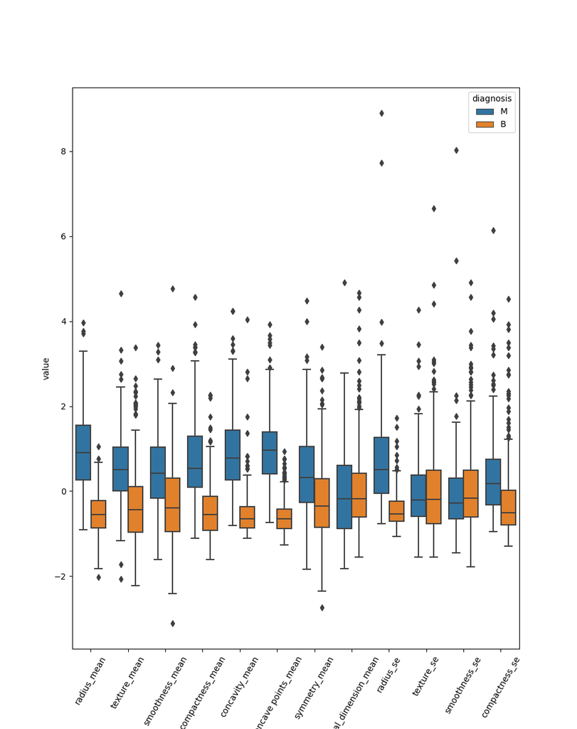

```python
plt.figure(figsize=(9.5,12))
sns.boxplot(x="features", y="value", hue="diagnosis", data=x_1)
plt.xticks(rotation=60)
```

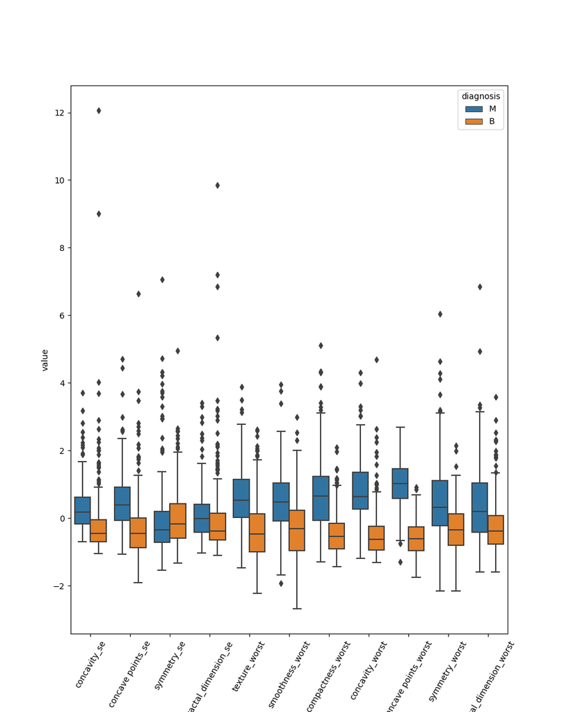

```python
plt.figure(figsize=(9.5,12))
sns.boxplot(x="features", y="value", hue="diagnosis", data=x_2)
plt.xticks(rotation=60)
```

По приведенным данным наиболее подходящим признаком для отделения доброкачественных от злокачественных образований кажется в первую очередь **concave points_mean** ( и высокоскореллированный с ним concave points_worst). Также полезными будут в первую очередь:

- radius_mean
- concavity_mean
- radius_se

## Part 2. kNN

### Формулировка второй части задачи:

Разбейте данные на train-test, отложив 30% выборки для тестирования

Приведите все непрерывные переменные к одному масштабу при помощи стандартизации. Кратко поясните, почему стандартизация здесь нужна

Постройте модель kNN "из коробки" без настройки параметров. Оцените метрики качества бинарной классификации (accuracy, precision, recall, f1_score), постройте ROC-кривую и посчитайте площадь под ней

Теперь проведите настройку параметра числа соседей на кросс-валидации. Снова оцените результаты, стало ли лучше? :)

### kNN with default parameters

```python
from sklearn.model_selection import StratifiedKFold, train_test_split
from sklearn.preprocessing import StandardScaler

from sklearn.neighbors import KNeighborsClassifier
from sklearn.metrics import classification_report, roc_curve, roc_auc_score, auc
from sklearn.metrics import accuracy_score, precision_score, recall_score, f1_score


data = pd.read_csv('data/data.csv')
data = data.drop('Unnamed: 32', axis=1)
```

```python
# Подготовим данные для обучения модели
diag = data.diagnosis.replace('M', 1).replace('B', 0)
# diag = data.diagnosis
data = data.drop(['id', 'diagnosis'], axis = 1 )
```

```python
# Разбиваем на train-test выборки в соотношении 70 на 30
X_train, X_test, y_train, y_test = train_test_split(data, diag, test_size=0.3, random_state=37)

print('Shape of training set is {0},{1}\nShape of testing set is {2},{3}'.format(X_train.shape, y_train.shape, X_test.shape, y_test.shape))

display(X_train.head(3), y_train.head(3))

# Нормализуем данные, т.к. сейчас их масштаб не соразмерен друг другу: есть параметры со средним значением - сотни,
# а есть, со средним значением на 4 порядка меньше
scaler = StandardScaler()
X_train_std = scaler.fit_transform(X_train)
X_test_std = scaler.transform(X_test)
```

```
Shape of training set is (398, 30),(398,)
Shape of testing set is (171, 30),(171,)
```

|  | radius_mean | texture_mean | perimeter_mean | area_mean | smoothness_mean | compactness_mean | concavity_mean | concave points_mean | symmetry_mean | fractal_dimension_mean | ... | radius_worst | texture_worst | perimeter_worst | area_worst | smoothness_worst | compactness_worst | concavity_worst | concave points_worst | symmetry_worst | fractal_dimension_worst |
| --- | --- | --- | --- | --- | --- | --- | --- | --- | --- | --- | --- | --- | --- | --- | --- | --- | --- | --- | --- | --- | --- |
| 371 | 15.19 | 13.21 | 97.65 | 711.8 | 0.07963 | 0.06934 | 0.03393 | 0.02657 | 0.1721 | 0.05544 | ... | 16.20 | 15.73 | 104.50 | 819.1 | 0.1126 | 0.1737 | 0.1362 | 0.08178 | 0.2487 | 0.06766 |
| 376 | 10.57 | 20.22 | 70.15 | 338.3 | 0.09073 | 0.16600 | 0.22800 | 0.05941 | 0.2188 | 0.08450 | ... | 10.85 | 22.82 | 76.51 | 351.9 | 0.1143 | 0.3619 | 0.6030 | 0.14650 | 0.2597 | 0.12000 |
| 168 | 17.47 | 24.68 | 116.10 | 984.6 | 0.10490 | 0.16030 | 0.21590 | 0.10430 | 0.1538 | 0.06365 | ... | 23.14 | 32.33 | 155.30 | 1660.0 | 0.1376 | 0.3830 | 0.4890 | 0.17210 | 0.2160 | 0.09300 |

3 rows × 30 columns

```
371    0
376    0
168    1
Name: diagnosis, dtype: int64
```

```python
def quality(prediction_y, true_y):
    accuracy = accuracy_score(prediction_y, true_y)
    precision = precision_score(prediction_y, true_y)
    recall = recall_score(prediction_y, true_y)
    f1 = f1_score(prediction_y, true_y)
    print("Accuracy:  {:.3f}\nPrecision: {:.3f}\nRecall:    {:.3f}\nF1-score:  {:.3f}".format(
        accuracy, precision, recall, f1
    ))
```

```python
classifier = KNeighborsClassifier()
classifier.fit(X_train_std, y_train)
prediction = classifier.predict(X_test_std)
quality(y_test, prediction)
```

```
Accuracy:  0.959
Precision: 0.948
Recall:    0.932
F1-score:  0.940
```

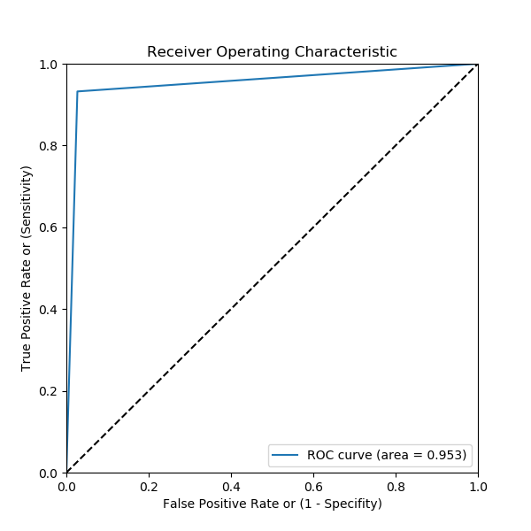

```python
# Compute fpr, tpr, thresholds and roc auc
fpr, tpr, thresholds = roc_curve(y_test, prediction)
roc_auc = roc_auc_score(y_test, prediction)

# Plot ROC curve
plt.figure(figsize=(6,6))
plt.plot(fpr, tpr, label='ROC curve (area = %0.3f)' % roc_auc)
plt.plot([0, 1], [0, 1], 'k--')  # random predictions curve
plt.xlim([0.0, 1.0])
plt.ylim([0.0, 1.0])
plt.xlabel('False Positive Rate or (1 - Specifity)')
plt.ylabel('True Positive Rate or (Sensitivity)')
plt.title('Receiver Operating Characteristic')
plt.legend(loc="lower right")
```

### Tuning kNN parameters

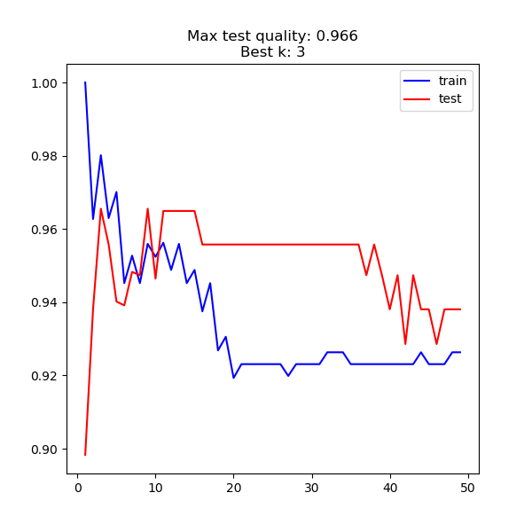

```python
neighbors = range(1, 50)
f1_score_train = []
f1_score_test = []
for k in neighbors:
    knn = KNeighborsClassifier(n_neighbors=k)
    knn.fit(X_train_std, y_train)
    f1_score_train.append(f1_score(knn.predict(X_train_std), y_train))
    f1_score_test.append(f1_score(knn.predict(X_test_std), y_test))

plt.figure(figsize=(6,6))
plt.plot(neighbors, f1_score_train, color='blue', label='train')
plt.plot(neighbors, f1_score_test, color='red', label='test')
plt.title("Max test quality: {:.3f}\nBest k: {}".format(max(f1_score_test), np.argmax(f1_score_test)+1))
plt.legend();
```

Таким образом наилучший результат достигается при количестве соседей равном 3.

Далее построим ROC-кривую для случая n_neighbors=3

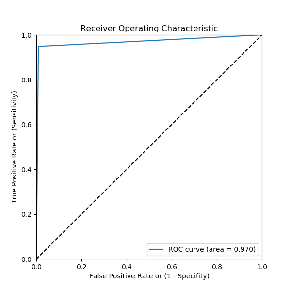

```python
knn = KNeighborsClassifier(n_neighbors=3)
knn.fit(X_train_std, y_train)
prediction = knn.predict(X_test_std)

fpr, tpr, thresholds = roc_curve(y_test, prediction)
roc_auc = roc_auc_score(y_test, prediction)

# Plot ROC curve
plt.figure(figsize=(6,6))
plt.plot(fpr, tpr, label='ROC curve (area = %0.3f)' % roc_auc)
plt.plot([0, 1], [0, 1], 'k--')  # random predictions curve
plt.xlim([0.0, 1.0])
plt.ylim([0.0, 1.0])
plt.xlabel('False Positive Rate or (1 - Specifity)')
plt.ylabel('True Positive Rate or (Sensitivity)')
plt.title('Receiver Operating Characteristic')
plt.legend(loc="lower right")
```

### Cross-validation

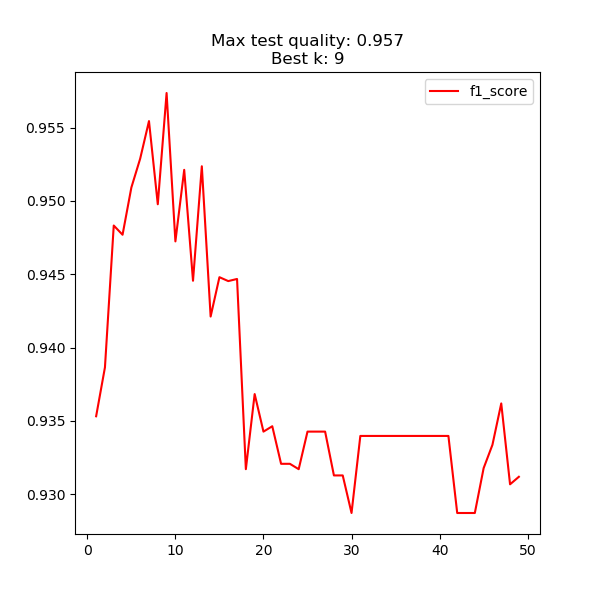

```python
from sklearn.model_selection import cross_val_score
import sklearn

data_std = scaler.transform(data)

neighbors = range(1, 50)
f1_scores = []
for k in neighbors:
    knn = KNeighborsClassifier(n_neighbors=k)
    scores = cross_val_score(knn, data_std, diag, cv=10, scoring='f1')
    f1_scores.append(scores.mean())

plt.figure(figsize=(6,6))
plt.plot(neighbors, f1_scores, color='red', label='f1_score')
plt.title("Max test quality: {:.3f}\nBest k: {}".format(max(f1_scores), np.argmax(f1_scores)+1))
plt.legend();
```

Кросс-валидация не привела к увеличению точности (f1=0.957, при ручном разбиении на train-test f1=0.966)

### Working on reduced set

В первой части был выделен набор данных из 23 параметров (после удаления части параметров высокоскореллированных друг с другом). Интересно посмотреть, какую точность можно получить на таком уменьшенном датасете.

```python
# Подготовим данные для обучения модели
diag = data_filtered.diagnosis.replace('M', 1).replace('B', 0)
# diag = data.diagnosis
data = data_filtered.drop(['diagnosis'], axis = 1 )

# Нормализуем данные, т.к. сейчас их масштаб не соразмерен друг другу: есть параметры со средним значением - сотни,
# а есть, со средним значением на 4 порядка меньше

# Разбиваем на train-test выборки в соотношении 70 на 30
X_train, X_test, y_train, y_test = train_test_split(data, diag, test_size=0.3, random_state=37)

print('Shape of training set is {0},{1}\nShape of testing set is {2},{3}'.format(X_train.shape, y_train.shape, X_test.shape, y_test.shape))

X_train_std = scaler.fit_transform(X_train)
X_test_std = scaler.transform(X_test)
```

```
Shape of training set is (398, 23),(398,)
Shape of testing set is (171, 23),(171,)
```

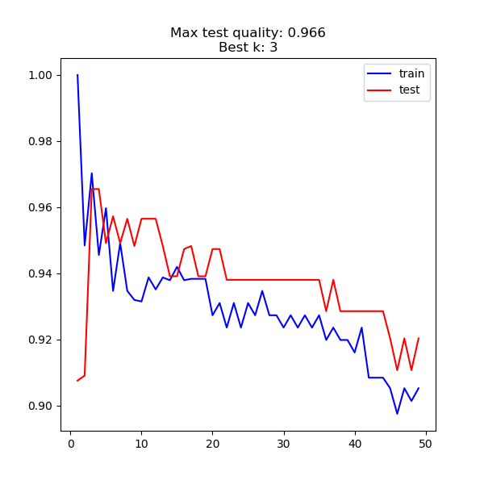

```python
neighbors = range(1, 50)
f1_score_train = []
f1_score_test = []
for k in neighbors:
    knn = KNeighborsClassifier(n_neighbors=k)
    knn.fit(X_train_std, y_train)
    f1_score_train.append(f1_score(knn.predict(X_train_std), y_train))
    f1_score_test.append(f1_score(knn.predict(X_test_std), y_test))

plt.figure(figsize=(6,6))
plt.plot(neighbors, f1_score_train, color='blue', label='train')
plt.plot(neighbors, f1_score_test, color='red', label='test')
plt.title("Max test quality: {:.3f}\nBest k: {}".format(max(f1_score_test), np.argmax(f1_score_test)+1))
plt.legend();
```

Вывод: При удалении дублирующих друг друга параметров точность не упала (или, по крайней мере, не изменилась существенно)

## Working on even more reduced set

В конце первого раздела было выделено 4 параметра, которые, как ожидается, наиболее важны для предсказания целевой переменной Интересно в рамках эксперимента посмотреть на точность модели, обученной только на этих 4 параметрах

```python
data = pd.read_csv('data/data.csv')
data = data.drop('Unnamed: 32', axis=1)

# Подготовим данные для обучения модели
diag = data.diagnosis.replace('M', 1).replace('B', 0)
# diag = data.diagnosis
data = data.loc[:, ['concave points_mean', 'radius_mean', 'concavity_mean', 'radius_se']]

# Разбиваем на train-test выборки в соотношении 70 на 30
X_train, X_test, y_train, y_test = train_test_split(data, diag, test_size=0.3, random_state=37)

X_train_std = scaler.fit_transform(X_train)
X_test_std = scaler.transform(X_test)
```

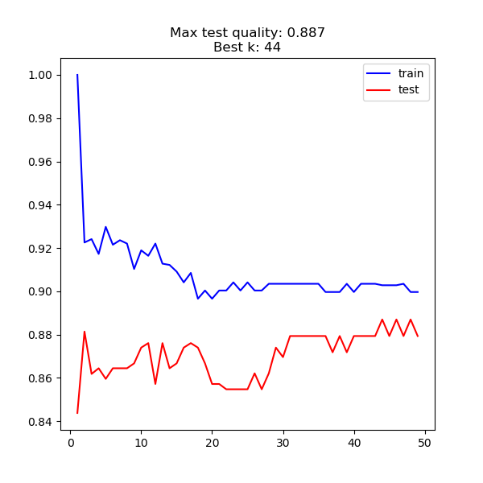

```python
neighbors = range(1, 50)
f1_score_train = []
f1_score_test = []
for k in neighbors:
    knn = KNeighborsClassifier(n_neighbors=k)
    knn.fit(X_train_std, y_train)
    f1_score_train.append(f1_score(knn.predict(X_train_std), y_train))
    f1_score_test.append(f1_score(knn.predict(X_test_std), y_test))

plt.figure(figsize=(6,6))
plt.plot(neighbors, f1_score_train, color='blue', label='train')
plt.plot(neighbors, f1_score_test, color='red', label='test')
plt.title("Max test quality: {:.3f}\nBest k: {}".format(max(f1_score_test), np.argmax(f1_score_test)+1))
plt.legend();
```

Вывод: ожидаемо, при существенном сокращении используемых параметров, точность упала

### Автоматический подбор гиперпараметров

Попробуем еще улучшить нашу модель при помощи автоматического подбора гиперпараметров

```python
%%time
from sklearn.model_selection import GridSearchCV

data = pd.read_csv('data/data.csv')
data = data.drop('Unnamed: 32', axis=1)
diag = data.diagnosis.replace('M', 1).replace('B', 0)
data = data.drop(['id', 'diagnosis'], axis = 1 )

# Разбиваем на train-test выборки в соотношении 70 на 30
X_train, X_test, y_train, y_test = train_test_split(data, diag, test_size=0.3, random_state=37)

scaler = StandardScaler()
X_train_std = scaler.fit_transform(X_train)
X_test_std = scaler.transform(X_test)

param_grid = {
        'n_neighbors': range(1, 50),
        'p': range(1, 4)
}

knn = KNeighborsClassifier()

grid_search = GridSearchCV(knn, param_grid, cv=10, scoring='f1')
grid_search.fit(X_train_std, y_train)

print("Best CV score: {:.3f}, best CV k: {}, best CV p: {}".format(
    grid_search.best_score_, grid_search.best_estimator_.n_neighbors, grid_search.best_estimator_.p)
)

test_predictions = grid_search.best_estimator_.predict(X_test_std)
print("Resulting test score: {:.3f}".format(f1_score(test_predictions, y_test)))
```

```
Best CV score: 0.960, best CV k: 1, best CV p: 1
Resulting test score: 0.898
Wall time: 9.94 s
```

```python
from sklearn.model_selection import RandomizedSearchCV

rand_search = RandomizedSearchCV(knn, param_grid, cv=10, scoring='f1', random_state=37)
rand_search.fit(X_train_std, y_train)

print("Best CV score: {:.3f}, best CV k: {}, best CV p: {}".format(
    rand_search.best_score_, rand_search.best_estimator_.n_neighbors, rand_search.best_estimator_.p)
)

test_predictions = rand_search.best_estimator_.predict(X_test_std)
print("Resulting test score: {:.3f}".format(f1_score(test_predictions, y_test)))
```

```
Best CV score: 0.934, best CV k: 13, best CV p: 2
Resulting test score: 0.965
```

## Вопросы к проверяющему:

Некоторые вещи не понял, буду благодарен, если поясните

1. Если в функции train_test_split не задачать жестко параметр random_state, то результаты начинают существенно плавать. Более того, при разных randsom_state'ах меняется то, при каком параметре n_neighbors получается наилучшая точность. Это нормально и связано с тем, что у нас слишком маленький датасет?
2. Результаты с кросс-валидацией не лучше, чем при ручном разбиении на train-test (70/30) наборы данных? Это ожидаемо?
3. Кажется что-то не так пошло с автоматическим подбором параметров c помощью GridSearchCV. Не могу понять, почему он не находит значение, хотя бы равное тому, которое удалось найти вручную? На тестовой выборке его результаты даже хуже чем у RandomizedSearchCV
4. ROC-кривые не слишком похожи на те примеры, которые я видел в интернете. Они вообще правильные? И пока мне они не выглядят слишком информативно, какую полезную информацию мы можем считать с них глазами в реальной практике? На что обращать внимание?
5. С учётом специфики задачи, возможно следовало дополнительно тюнить f1 так, чтобы recall имел больший вес?
6. По boxplot в конце первой части видно, что есть достаточно существенные выбросы в некоторых параметрах. Нужно ли их оставлять в датасете или следует удалить?

Приветствуются любые замечания/правки/вопросы. Спасибо

### Формулировка бонусной части задачи (не сделано, планирую после соответствующей лекции)

Бонусное задание для любопытствующих, к которому можно вернуться после изучения логистической регрессии:

Как вы помните, логистическая регрессия плохо относится к линейно-зависимым признакам, уберите переменные, корреляция пирсона между которыми превышает 0.85

Постройте модель логистической регрессии "из коробки" без настройки параметров. Оцените метрики качества бинарной классификации (accuracy, precision, recall, f1_score), постройте ROC-кривую и посчитайте площадь под ней. Визуализируйте влияние коэффициентов на целевую переменную.

Теперь проведите настройку параметра регуляризации C на кросс-валидации (LogisticRegressionCV). Снова оцените результаты и постройте визуализацию влияния коэффициентов на целевую переменную. Сделайте интересные выводы :)

Какая из двух настроенных моделей, kNN или логистическая регрессия оказалась, в итоге, лучше?

TODO: сделать после лекций по логистической регрессии